This is going to be real quick tutorial/how to on using Neo4j with Python. The graph will not as of right now be highly interesting, but it is more of to show the mechanics of pushing data to a Neo4j graph. I am making the assumption that you already have Neo4j installed and setup on your current machine, or have it properly networked so that you can connect to it from your current machine.

```python
from IPython.display import Image

p = open('neo4jpass', 'r')
password = p.read().split()
username, password = password[0], password[1]
```

## Neo4j-driver

I have currently looked at two different packages for working with Neo4j, the first is the basic neo4j-driver package. It seemed to work well, but compared to the next package was a little bit more verbose. The following code demonstrates how to start a session, create an entry, quiery for that entry, and delete that entry or delete all entries.

```python
# Begin with importing the dependencies as follows.
from neo4j.v1 import GraphDatabase, basic_auth

#Establish a connection to the neo4j database (replace "bolt://localhost:7687" with your db address if different)
#username, and password are string vlaues in the format ("neo4j", "password)
driver = GraphDatabase.driver("bolt://localhost:7687", auth=basic_auth(username, password))

#Once connected create a session that all further actions will utilize.
session = driver.session()
```

All actions using this package seem to be initiated by `session.run()` inside this goes your cipher query followed by a dictionary with keys corresponding to the fields in the quiery and values containing what you want in those fields.The following are examples of how to create nodes using this method. I was unable to easily create relationships this way.

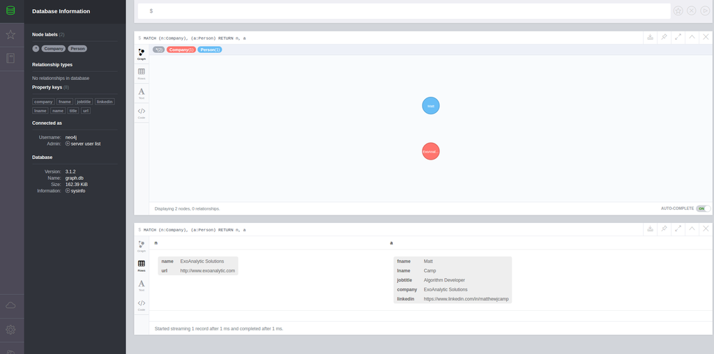

```python
person_dict =  {"fname": "Matt", "lname": "Camp", "company": "ExoAnalytic Solutions",
           "jobtitle": "Algorithm Developer", "linkedin": "https://www.linkedin.com/in/matthewjcamp"}

company_dict = {"name": "ExoAnalytic Solutions", "url": "http://www.exoanalytic.com"}

session.run("CREATE (a:Person {fname: {fname}, lname: {lname}, company: {company},\
                               jobtitle: {jobtitle}, linkedin: {linkedin}})", person_dict)

session.run("CREATE (a:Company {name: {name}, url: {url}})", company_dict)


Image(filename='Addmyself.png')
```

Now we will run a query to find ourselves using similary code as above.

```python
result = session.run("MATCH (a:Person) WHERE a.lname = {lname} "
                   "RETURN a.fname AS fname,a.lname AS lname,\
                   a.jobtitle AS jobtitle, a.linkedin AS linkedin",
                   {"lname": "Camp"})

#this will return an object containing all the quiery results that we then iterate through.
for record in result:
    print("Person: %s %s\nJob Title: %s\nLinkedIn: %s\n" % (record["fname"],\
                                                                       record["lname"],\
                                                                       record["jobtitle"],\
                                                                       record["linkedin"]))
```

[output not shown]

```python
# Will delete all results from the above query.
session.run("MATCH (a:Person) WHERE a.lname = {lname} DETACH DELETE a", {"lname": "Camp"})
# Will delete all nodes from the graph.
session.run("MATCH (n) DETACH DELETE n")
# close the session when you are done.
session.close()
```

## Py2neo

At this point in my expierence with neo4j, I am still learning the cipher language. Because of this I prefer `py2neo`, as it doesn't require writting cypher queries directly, but there is an option to be able to. The following will first add myself to the graph and then add several calendar events scraped from the internet with the appropriate relationships.

```python
from py2neo import authenticate, Graph, Node, Relationship, NodeSelector

# set up authentication parameters
authenticate("localhost:7474", username, password)

# connect to authenticated graph database
graph = Graph("http://localhost:7474/db/data/")
selector = NodeSelector(graph)
```

As you can see this code is much easier to read and than the previous. If you look at the picture of the graph you can see that it too, just makes sense, with a node that says "Matt" and an arrow that says "WORKS AT" connected to another node "ExoAnalytic Solutions." Attempting to do something similar in a relational database would reslult at best in a table of people that works at ExoAnalytic or two tables with lists of people and lists of companies all with a cryptic primary key that must be interperted by an anlyst or database admin.

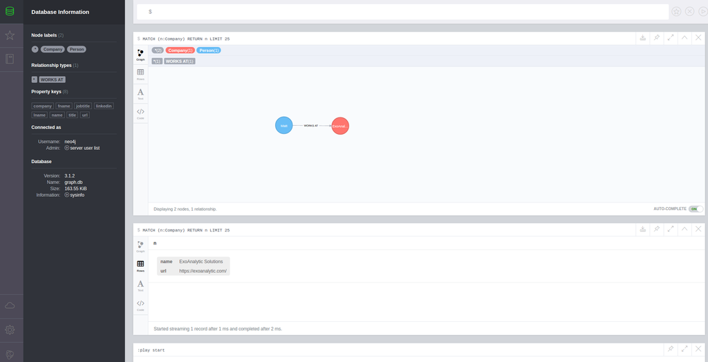

```python
#Each node gets saved as a variable before getting added to the graph.
myself = Node("Person", fname='Matt', lname='Camp',
              linkedin='https://www.linkedin.com/in/matthewjcamp/')

mycompany = Node("Company", name='ExoAnalytic Solutions', url='https://exoanalytic.com/')

myself2mycompany = Relationship(myself, "WORKS AT", mycompany, as_a='Algorithm Developer')

#Now we create the node on the graph
graph.create(myself)
graph.create(mycompany)
graph.create(myself2mycompany)
Image(filename='Addmyself2.png')
```

The calendar data needs to be scraped from the web and will be handled by some functions I have housed in my scrapers file. All the calendar data is stored in `calendar_dict`.

```python
from scrapers import *

calendar_dict = merge_calendars()
```

This is what the data looks like, just a dictionary with keys being the event name, and values containing a list with formated datetime, raw date extracted from the site, and the url of the site.

```python
calendar_dict[' UAH/AMRDEC Girls S&E Day']
```

```
(datetime.datetime(2017, 9, 23, 0, 0),
 '23 Sep 17',
 'http://www.huntsvilledefenseandspacecalendar.com/')
```

I know that my scraper function calls three calendars and because I want both the calendars and events to be nodes in the graph, I am going to create the calendar nodes first.

```python
mda_calendar = Node("Calendar", name='MDA Small Business Calendar',
                url='https://www.mda.mil/business/bus_calendar.html')

HSV_DnS_calendar = Node("Calendar", name='Huntsville Defense & Space Calendar',
                url='http://www.huntsvilledefenseandspacecalendar.com/')

hsv_chamber_calendar = Node("Calendar", name='Huntsville Chamber of Commerece Calendar',
                url='http://www.huntsvillealabamausa.com/index.php?option=com_content&view=article&id=190&Itemid=298')

graph.create(mda_calendar)
graph.create(HSV_DnS_calendar)
graph.create(hsv_chamber_calendar)
```

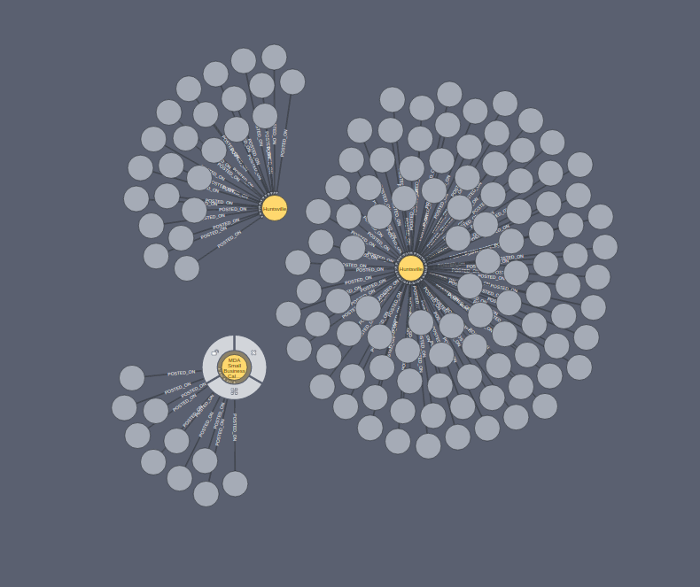

```python
for event_name, event_details in calendar_dict.items():
    calendar = selector.select("Calendar", url=event_details[2]).first()

    calendar_event = Node("CalendarEvent", name=event_name, date=str(event_details[0]))
    graph.create(calendar_event)
    calendar_rel = Relationship(calendar_event, "POSTED_ON", calendar,
                                scrape_date=str(datetime.date.today()))
    graph.create(calendar_rel)

Image(filename='CalendarNodes.png')
```

```python
graph.run("MATCH (a:Calendar) RETURN a.name").evaluate()
```

```
'MDA Small Business Calendar'
```

```python
graph.run("MATCH (a:CalendarEvent) RETURN a.event, a.date").data()
```

```
[{'a.date': '2017-04-01 00:00:00', 'a.event': None},
 {'a.date': '2017-07-19 00:00:00', 'a.event': None},
 {'a.date': '2017-04-06 00:00:00', 'a.event': None},
 {'a.date': '2017-04-18 00:00:00', 'a.event': None},
 {'a.date': '2017-02-09 00:00:00', 'a.event': None},
 {'a.date': '2017-03-14 00:00:00', 'a.event': None},
 {'a.date': '2017-03-12 00:00:00', 'a.event': None},
 {'a.date': '2017-03-14 00:00:00', 'a.event': None},
 {'a.date': '2017-04-24 00:00:00', 'a.event': None},
 {'a.date': '2017-03-02 00:00:00', 'a.event': None},
 {'a.date': '2017-04-10 00:00:00', 'a.event': None},
 {'a.date': '2017-04-23 00:00:00', 'a.event': None},
 {'a.date': 'None', 'a.event': None},
 {'a.date': '2017-03-23 00:00:00', 'a.event': None},
 {'a.date': '2017-02-13 00:00:00', 'a.event': None},
 {'a.date': 'None', 'a.event': None},
 {'a.date': '2017-03-09 00:00:00', 'a.event': None},
 {'a.date': '2017-02-27 00:00:00', 'a.event': None},
 {'a.date': 'None', 'a.event': None},
 {'a.date': '2017-06-14 00:00:00', 'a.event': None},
 {'a.date': '2017-01-25 00:00:00', 'a.event': None},
 {'a.date': '2017-04-16 00:00:00', 'a.event': None},
 {'a.date': 'None', 'a.event': None},
 {'a.date': '2017-11-12 00:00:00', 'a.event': None},
 {'a.date': 'None', 'a.event': None},
 {'a.date': '2017-04-27 00:00:00', 'a.event': None},
 {'a.date': '2017-02-21 00:00:00', 'a.event': None},
 {'a.date': '2017-10-14 00:00:00', 'a.event': None},
 {'a.date': '2017-04-04 00:00:00', 'a.event': None},
 {'a.date': '2017-03-25 00:00:00', 'a.event': None},
 {'a.date': '2017-09-22 00:00:00', 'a.event': None},
 {'a.date': '2017-02-28 00:00:00', 'a.event': None},
 {'a.date': '2017-09-04 00:00:00', 'a.event': None},
 {'a.date': 'None', 'a.event': None},
 {'a.date': '2017-03-20 00:00:00', 'a.event': None},
 {'a.date': '2017-03-23 00:00:00', 'a.event': None},
 {'a.date': '2017-06-06 00:00:00', 'a.event': None},
 {'a.date': '2017-03-02 00:00:00', 'a.event': None},
 {'a.date': 'None', 'a.event': None},
 {'a.date': '2017-07-22 00:00:00', 'a.event': None},
```

[output cut: 81 more lines]

```
 {'a.date': '2017-04-12 00:00:00', 'a.event': None},
 {'a.date': '2017-03-09 00:00:00', 'a.event': None},
 {'a.date': 'None', 'a.event': None},
 {'a.date': 'None', 'a.event': None},
 {'a.date': '2017-03-23 00:00:00', 'a.event': None},
 {'a.date': '2017-09-11 00:00:00', 'a.event': None},
 {'a.date': '2017-03-06 00:00:00', 'a.event': None},
 {'a.date': '2017-03-28 00:00:00', 'a.event': None},
 {'a.date': 'None', 'a.event': None},
 {'a.date': '2017-06-21 00:00:00', 'a.event': None},
 {'a.date': '2017-11-02 00:00:00', 'a.event': None},
 {'a.date': '2017-03-17 00:00:00', 'a.event': None},
 {'a.date': '2017-03-09 00:00:00', 'a.event': None},
 {'a.date': '2017-06-14 00:00:00', 'a.event': None},
 {'a.date': 'None', 'a.event': None}]
```

```python
graph.run("MATCH (a:CalendarEvent) DETACH DELETE a")
```

```
<py2neo.database.Cursor at 0x7f8494cea048>
```

```python
graph.run("MATCH (a:Calendar) DETACH DELETE a")
```

```
<py2neo.database.Cursor at 0x7f8494cead30>
```